# Recursos 07

8 actividades; 4 operarios; interrumpir o no interrumpir

# Enunciado

Considere el proyecto cuyo cuadro de prelaciones, duraciones (semanas) y operarios necesarios se adjunta, con 4 operarios disponibles. Se discute si merece la pena organizar el trabajo de modo que una actividad pueda interrumpirse y reanudarse más tarde (sin coste añadido) cuando los operarios hagan falta en otra más urgente.

1. Programe el proyecto con un planificador en paralelo y la regla «menor holgura total primero» suponiendo que las actividades **no** pueden interrumpirse. ¿Cuánto dura?

2. Repita suponiendo que sí pueden interrumpirse: en cada semana se vuelven a ordenar *todas* las actividades disponibles, también las empezadas, y una actividad en curso puede quedar parada si entra otra más prioritaria. ¿Cuánto dura? ¿Qué actividades se interrumpen y cuántas veces?

3. Compare las dos programaciones semana a semana. ¿De dónde sale la ganancia (si la hay)?

4. ¿Qué costes ocultos tiene interrumpir una actividad en la práctica? ¿Cuándo compensa?

Tabla 1: Cuadro de datos del enunciado

| activity | predecessor | duration | resources |
| --- | --- | --- | --- |
| A | --- | 6 | 4 |
| B | --- | 5 | 1 |
| C | A,B | 3 | 4 |
| D | C | 6 | 2 |
| E | B | 4 | 1 |
| F | C | 3 | 1 |
| G | E,F | 2 | 4 |
| H | D,G | 3 | 4 |

# Resolución

## Apartado 1

1. Programe el proyecto con un planificador en paralelo y la regla «menor holgura total primero» suponiendo que las actividades **no** pueden interrumpirse. ¿Cuánto dura?

Cálculo de los tiempos tempranos y tardíos de los sucesos y de las holguras totales paso a paso. El primer paso muestra el grafo resuelto; a partir del siguiente se calcula desde el principio (avance con los botones):

paso 0 de 25

[figure not shown]

Figura 1: Grafo PERT con tiempos y camino crítico (sin límite de operarios)

Tabla 2: Calendario sin límite de recursos (la regla de prioridad usa la holgura total)

[figure not shown]

Haz clic en un número de la tabla para ver cómo se calcula.

👆 **Interactivo:** haz clic en cualquier celda de la tabla para ver cómo se calcula (otro clic la deselecciona).

| Actividad | Duración | Inicio más temprano | Fin más temprano | Inicio más tardío | Fin más tardío | H total | H libre | H independiente |
| --- | --- | --- | --- | --- | --- | --- | --- | --- |
| A | 6 | 0 | 6 | 0 | 6 | 0 | 0 | 0 |
| B | 5 | 0 | 5 | 1 | 6 | 1 | 0 | 0 |
| C | 3 | 6 | 9 | 6 | 9 | 0 | 0 | 0 |
| D | 6 | 9 | 15 | 9 | 15 | 0 | 0 | 0 |
| E | 4 | 5 | 9 | 9 | 13 | 4 | 3 | 2 |
| F | 3 | 9 | 12 | 10 | 13 | 1 | 0 | 0 |
| G | 2 | 12 | 14 | 13 | 15 | 1 | 1 | 0 |
| H | 3 | 15 | 18 | 15 | 18 | 0 | 0 | 0 |

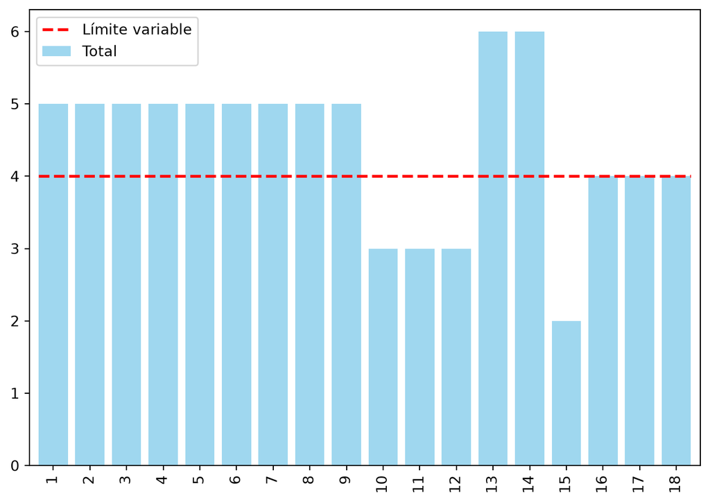

Figura 2: Cargas con los inicios más tempranos frente al límite

El planificador recorre las semanas: una actividad es *disponible* cuando han terminado sus predecesoras; las disponibles se ordenan por la regla (menor holgura total, luego menor duración) y entran mientras quepan en el límite. Sin interrupciones, las ya empezadas van primero.

Tabla 3: Programación sin interrupciones

|  | 1 | 2 | 3 | 4 | 5 | 6 | 7 | 8 | 9 | 10 | 11 | 12 | 13 | 14 | 15 | 16 | 17 | 18 | 19 | 20 | 21 | 22 | 23 | 24 | 25 |
| --- | --- | --- | --- | --- | --- | --- | --- | --- | --- | --- | --- | --- | --- | --- | --- | --- | --- | --- | --- | --- | --- | --- | --- | --- | --- |
| A | 4 | 4 | 4 | 4 | 4 | 4 |  |  |  |  |  |  |  |  |  |  |  |  |  |  |  |  |  |  |  |
| B |  |  |  |  |  |  | 1 | 1 | 1 | 1 | 1 |  |  |  |  |  |  |  |  |  |  |  |  |  |  |
| C |  |  |  |  |  |  |  |  |  |  |  | 4 | 4 | 4 |  |  |  |  |  |  |  |  |  |  |  |
| D |  |  |  |  |  |  |  |  |  |  |  |  |  |  | 2 | 2 | 2 | 2 | 2 | 2 |  |  |  |  |  |
| E |  |  |  |  |  |  |  |  |  |  |  |  |  |  | 1 | 1 | 1 | 1 |  |  |  |  |  |  |  |
| F |  |  |  |  |  |  |  |  |  |  |  |  |  |  | 1 | 1 | 1 |  |  |  |  |  |  |  |  |
| G |  |  |  |  |  |  |  |  |  |  |  |  |  |  |  |  |  |  |  |  | 4 | 4 |  |  |  |
| H |  |  |  |  |  |  |  |  |  |  |  |  |  |  |  |  |  |  |  |  |  |  | 4 | 4 | 4 |
| Total | 4 | 4 | 4 | 4 | 4 | 4 | 1 | 1 | 1 | 1 | 1 | 4 | 4 | 4 | 4 | 4 | 4 | 3 | 2 | 2 | 4 | 4 | 4 | 4 | 4 |
| ≤ límite | sí | sí | sí | sí | sí | sí | sí | sí | sí | sí | sí | sí | sí | sí | sí | sí | sí | sí | sí | sí | sí | sí | sí | sí | sí |

Sin interrupciones el proyecto dura 25 semanas (mínimo sin límite de recursos: 18).

## Apartado 2

2. Repita suponiendo que sí pueden interrumpirse: en cada semana se vuelven a ordenar *todas* las actividades disponibles, también las empezadas, y una actividad en curso puede quedar parada si entra otra más prioritaria. ¿Cuánto dura? ¿Qué actividades se interrumpen y cuántas veces?

Tabla 4: Programación con interrupciones permitidas

|  | 1 | 2 | 3 | 4 | 5 | 6 | 7 | 8 | 9 | 10 | 11 | 12 | 13 | 14 | 15 | 16 | 17 | 18 | 19 | 20 | 21 | 22 | 23 | 24 | 25 |
| --- | --- | --- | --- | --- | --- | --- | --- | --- | --- | --- | --- | --- | --- | --- | --- | --- | --- | --- | --- | --- | --- | --- | --- | --- | --- |
| A | 4 | 4 | 4 | 4 | 4 | 4 |  |  |  |  |  |  |  |  |  |  |  |  |  |  |  |  |  |  |  |
| B |  |  |  |  |  |  | 1 | 1 | 1 | 1 | 1 |  |  |  |  |  |  |  |  |  |  |  |  |  |  |
| C |  |  |  |  |  |  |  |  |  |  |  | 4 | 4 | 4 |  |  |  |  |  |  |  |  |  |  |  |
| D |  |  |  |  |  |  |  |  |  |  |  |  |  |  | 2 | 2 | 2 | 2 | 2 | 2 |  |  |  |  |  |
| E |  |  |  |  |  |  |  |  |  |  |  |  |  |  | 1 | 1 | 1 | 1 |  |  |  |  |  |  |  |
| F |  |  |  |  |  |  |  |  |  |  |  |  |  |  | 1 | 1 | 1 |  |  |  |  |  |  |  |  |
| G |  |  |  |  |  |  |  |  |  |  |  |  |  |  |  |  |  |  |  |  | 4 | 4 |  |  |  |
| H |  |  |  |  |  |  |  |  |  |  |  |  |  |  |  |  |  |  |  |  |  |  | 4 | 4 | 4 |
| Total | 4 | 4 | 4 | 4 | 4 | 4 | 1 | 1 | 1 | 1 | 1 | 4 | 4 | 4 | 4 | 4 | 4 | 3 | 2 | 2 | 4 | 4 | 4 | 4 | 4 |
| ≤ límite | sí | sí | sí | sí | sí | sí | sí | sí | sí | sí | sí | sí | sí | sí | sí | sí | sí | sí | sí | sí | sí | sí | sí | sí | sí |

Con interrupciones el proyecto dura 25 semanas. Ninguna actividad llega a interrumpirse.

## Apartado 3

3. Compare las dos programaciones semana a semana. ¿De dónde sale la ganancia (si la hay)?

Tabla 5: Inicio y fin de cada actividad en las dos programaciones

|  | inicio (no interr.) | fin (no interr.) | inicio (interr.) | fin (interr.) | semanas trabajadas (interr.) |
| --- | --- | --- | --- | --- | --- |
| A | 1 | 6 | 1 | 6 | 6 |
| B | 7 | 11 | 7 | 11 | 5 |
| C | 12 | 14 | 12 | 14 | 3 |
| D | 15 | 20 | 15 | 20 | 6 |
| E | 15 | 18 | 15 | 18 | 4 |
| F | 15 | 17 | 15 | 17 | 3 |
| G | 21 | 22 | 21 | 22 | 2 |
| H | 23 | 25 | 23 | 25 | 3 |

Si hay ganancia, viene de que al permitir interrumpir no hay que esperar a que termine una actividad poco urgente para liberar operarios: una actividad crítica puede entrar en cuanto está disponible. Si no la hay, es que la regla de prioridad ya había evitado bloquear el recurso con actividades holgadas. Interrumpir nunca empeora la duración con este planificador (el no interrumpible es un caso particular), pero puede fragmentar mucho el trabajo.

## Apartado 4

4. ¿Qué costes ocultos tiene interrumpir una actividad en la práctica? ¿Cuándo compensa?

Interrumpir tiene costes que el modelo ignora: volver a montar y desmontar (tiempos de preparación), pérdida de ritmo y de aprendizaje, el material en curso inmovilizado, la coordinación de los operarios y la dificultad de seguimiento. Compensa cuando el ahorro de plazo vale más que esos costes: actividades largas, modulares (pueden partirse en lotes) y sin costes de preparación apreciables; no compensa en tareas con fraguados, curados o procesos continuos.